# Sahil_A8

[interactive chart not shown]

In the map above, I’ve placed a marker at the location of the Antioch BART station; this is the North-Easternernmost stop from SF. Above is the distribution of population and BART commuters in Bay Area PUMAs. Livermore/Pleasanton seems to be the highest, but this can be misleading as it’s a raw count and not density. The differential sizes is a factor that can skew our results.

[interactive chart not shown]

Livermore/Pleasanton might have large number of riders, but it’s been diluted across a large area. If it was a dark color, we might think it’s a high density of BART riders that are very spread out.

[interactive chart not shown]

The above results show the Mahalanobis matching technique. It looks reasonable as most of these areas have no adjacent BART stations.

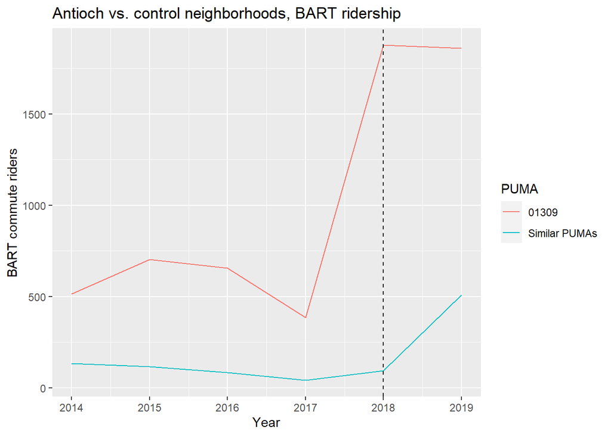

The slope between 2017 and 2018 is what we want to focus on. The effect size of the treatment is very large in 2018 after the station was opened. It looks like that for “Similar PUMAs,” everyone started riding BART more, but this was especially so in PUMA 01309.

```
##
## Call:
## lm(formula = bart ~ treated * time, data = transit_did)
##
## Residuals:
##     Min      1Q  Median      3Q     Max
## -301.10  -93.83  -53.30   64.67 1135.90
##
## Coefficients:
##              Estimate Std. Error t value Pr(>|t|)
## (Intercept)     93.82      36.51   2.570  0.01259 *
## treated        470.68     121.08   3.887  0.00025 ***
## time           207.28      63.23   3.278  0.00172 **
## treated:time  1097.22     209.72   5.232 2.11e-06 ***
## ---
## Signif. codes:  0 '***' 0.001 '**' 0.01 '*' 0.05 '.' 0.1 ' ' 1
##
## Residual standard error: 230.9 on 62 degrees of freedom
## Multiple R-squared:  0.6682, Adjusted R-squared:  0.6522
## F-statistic: 41.63 on 3 and 62 DF,  p-value: 7.327e-15
```

Explanation:

“treated” is the difference between 01309 and similar PUMAs before the treatment. The difference we don’t want to account for, as there existed differences between the treated and control group anyways.

“time” is comparing Similar PUMAs before the treatment to after the treatment. This is the difference in the control group which we don’t want to account for either.

The “treated:time” is the diff-in-diff; difference before and after the treatment. Barring the above differences we want to account for the unique contribution of the BART station between the two PUMAs.

We can see the treated:time is statistically significant, thus our BART station helped improve BART ridership in 01309 significantly.

A lot of assumptions were made with this analysis: We chose to evaluate, bart, which may not be the most pronounced or important possible causal effect of a BART station to evaluate. Perhaps the key ridership is arriving at the Antioch station, not leaving from it.

We are assuming that respondents picked “Subway or elevated car” in the ACS questionnaire to represent a BART commute trip.

We did not match based on any other variables other than 2014-2017 train ridership. For example, we could have “controlled for” other variables like employment, income, demographics, in the same way we would have done a multiple regression.

We are using PUMS data which may introduce greater noise because of lower sample size relative to other possible datasets.

```
##    rowname               base             stderr
##  Length:4           Min.   :  93.83   Min.   : 18.71
##  Class :character   1st Qu.: 178.91   1st Qu.: 38.08
##  Mode  :character   Median : 338.98   Median :131.27
##                     Mean   : 467.25   Mean   :193.81
##                     3rd Qu.: 627.31   3rd Qu.:287.00
##                     Max.   :1097.22   Max.   :493.96
```